# CSCI E-63C Week 12 Problem Set

# Preface

This week problem set will explore behavior of support vector classifiers and SVMs (following the distinction made in ISLR) on WiFi localization dataset from UCI ML archive. We worked with it on multiple occasions before (most recently two weeks ago evaluating performance of logistic regression, discriminant analysis and KNN on it). As two weeks ago we are going to convert the four-levels outcome in the data file to the binary one indicating localization at the third location:

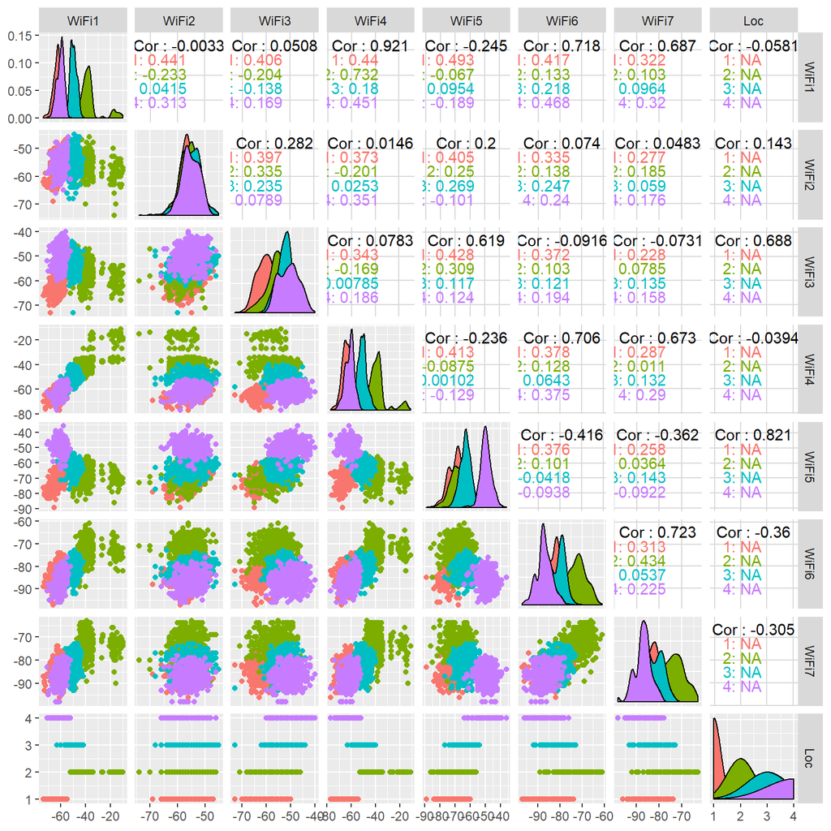

```r
wifiLocDat <- read.table("wifi_localization.txt",sep="\t")
colnames(wifiLocDat) <- c(paste0("WiFi",1:7),"Loc")
ggpairs(wifiLocDat,aes(colour=factor(Loc)))
```

```r
wifiLocDat[,"Loc3"] <- factor(wifiLocDat[,"Loc"]==3)
wifiLocDat <- wifiLocDat[,colnames(wifiLocDat)!="Loc"]
dim(wifiLocDat)
```

```
## [1] 2000    8
```

```r
summary(wifiLocDat)
```

```
##      WiFi1            WiFi2            WiFi3            WiFi4
##  Min.   :-74.00   Min.   :-74.00   Min.   :-73.00   Min.   :-77.00
##  1st Qu.:-61.00   1st Qu.:-58.00   1st Qu.:-58.00   1st Qu.:-63.00
##  Median :-55.00   Median :-56.00   Median :-55.00   Median :-56.00
##  Mean   :-52.33   Mean   :-55.62   Mean   :-54.96   Mean   :-53.57
##  3rd Qu.:-46.00   3rd Qu.:-53.00   3rd Qu.:-51.00   3rd Qu.:-46.00
##  Max.   :-10.00   Max.   :-45.00   Max.   :-40.00   Max.   :-11.00
##      WiFi5            WiFi6            WiFi7           Loc3
##  Min.   :-89.00   Min.   :-97.00   Min.   :-98.00   FALSE:1500
##  1st Qu.:-69.00   1st Qu.:-86.00   1st Qu.:-87.00   TRUE : 500
##  Median :-64.00   Median :-82.00   Median :-83.00
##  Mean   :-62.64   Mean   :-80.98   Mean   :-81.73
##  3rd Qu.:-56.00   3rd Qu.:-77.00   3rd Qu.:-78.00
##  Max.   :-36.00   Max.   :-61.00   Max.   :-63.00
```

```r
head(wifiLocDat)
```

```
##   WiFi1 WiFi2 WiFi3 WiFi4 WiFi5 WiFi6 WiFi7  Loc3
## 1   -64   -56   -61   -66   -71   -82   -81 FALSE
## 2   -68   -57   -61   -65   -71   -85   -85 FALSE
## 3   -63   -60   -60   -67   -76   -85   -84 FALSE
## 4   -61   -60   -68   -62   -77   -90   -80 FALSE
## 5   -63   -65   -60   -63   -77   -81   -87 FALSE
## 6   -64   -55   -63   -66   -76   -88   -83 FALSE
```

Here we will use SVM implementation available in library `e1071` to fit classifiers with linear and radial (polynomial for extra points) kernels and compare their relative performance as well as to that of random forest and KNN.

# Problem 1 (20 points): support vector classifier (i.e. using linear kernel)

Use `svm` from library `e1071` with `kernel="linear"` to fit classifier (e.g. ISLR Ch.9.6.1) to the entire WiFi localization dataset setting parameter `cost` to 0.001, 1, 1000 and 1 mln. Describe how this change in parameter `cost` affects model fitting process (hint: the difficulty of the underlying optimization problem increases with cost – can you explain what drives it?) and its outcome (how does the number of support vectors change with `cost`?) and what are the implications of that. Explain why change in `cost` value impacts number of support vectors found. (Hint: there is an answer in ISLR.) Use `tune` function from library `e1071` (see ISLR Ch.9.6.1 for details and examples of usage) to determine approximate value of cost (in the range between 0.1 and 100 – the suggested range spanning ordes of magnitude should hint that the density of the grid should be approximately logarithmic – e.g. 1, 3, 10, … or 1, 2, 5, 10, … etc.) that yields the lowest error in cross-validation employed by `tune`. Setup a resampling procedure repeatedly splitting entire dataset into training and test, using training data to `tune` cost value and test dataset to estimate classification error. Report and discuss distributions of test errors from this procedure and selected values of `cost`.

```r
# cost=0.001:
svmfit <- svm(Loc3~., data=wifiLocDat, kernel="linear", cost=0.001, scale=TRUE)
summary(svmfit)
```

```
##
## Call:
## svm(formula = Loc3 ~ ., data = wifiLocDat, kernel = "linear", cost = 0.001,
##     scale = TRUE)
##
##
## Parameters:
##    SVM-Type:  C-classification
##  SVM-Kernel:  linear
##        cost:  0.001
##
## Number of Support Vectors:  1013
##
##  ( 513 500 )
##
##
## Number of Classes:  2
##
## Levels:
##  FALSE TRUE
```

```r
table(predict(svmfit),wifiLocDat$Loc3)
```

```
##
##         FALSE TRUE
##   FALSE  1500  500
##   TRUE      0    0
```

```r
# cost=1:
svmfit <- svm(Loc3~., data=wifiLocDat, kernel="linear", cost=1, scale=TRUE)
summary(svmfit)
```

```
##
## Call:
## svm(formula = Loc3 ~ ., data = wifiLocDat, kernel = "linear", cost = 1,
##     scale = TRUE)
##
##
## Parameters:
##    SVM-Type:  C-classification
##  SVM-Kernel:  linear
##        cost:  1
##
## Number of Support Vectors:  1000
##
##  ( 501 499 )
##
##
## Number of Classes:  2
##
## Levels:
##  FALSE TRUE
```

```r
table(predict(svmfit),wifiLocDat$Loc3)
```

```
##
##         FALSE TRUE
##   FALSE  1435  371
##   TRUE     65  129
```

```r
# cost=1000:
svmfit <- svm(Loc3~., data=wifiLocDat, kernel="linear", cost=1000, scale=TRUE)
summary(svmfit)
```

```
##
## Call:
## svm(formula = Loc3 ~ ., data = wifiLocDat, kernel = "linear", cost = 1000,
##     scale = TRUE)
##
##
## Parameters:
##    SVM-Type:  C-classification
##  SVM-Kernel:  linear
##        cost:  1000
##
## Number of Support Vectors:  1018
##
##  ( 521 497 )
##
##
## Number of Classes:  2
##
## Levels:
##  FALSE TRUE
```

```r
table(predict(svmfit),wifiLocDat$Loc3)
```

```
##
##         FALSE TRUE
##   FALSE  1500  500
##   TRUE      0    0
```

```r
# cost=1,000,000:
svmfit <- svm(Loc3~., data=wifiLocDat, kernel="linear", cost=1000000, scale=TRUE)
summary(svmfit)
```

```
##
## Call:
## svm(formula = Loc3 ~ ., data = wifiLocDat, kernel = "linear", cost = 1e+06,
##     scale = TRUE)
##
##
## Parameters:
##    SVM-Type:  C-classification
##  SVM-Kernel:  linear
##        cost:  1e+06
##
## Number of Support Vectors:  450
##
##  ( 189 261 )
##
##
## Number of Classes:  2
##
## Levels:
##  FALSE TRUE
```

```r
table(predict(svmfit),wifiLocDat$Loc3)
```

```
##
##         FALSE TRUE
##   FALSE   908  125
##   TRUE    592  375
```

Note that for the cost values of 1000 and 1000000 the model produced warnings that the maximum number of iterations was exceeded therefore the model did not converge.

```r
# tune cost by cross-validation:
set.seed(1)
tune.out <- tune(svm, Loc3~., data=wifiLocDat, kernel="linear",
                 ranges=list(cost=c(0.001, 0.01, 0.1, 1, 5, 10, 100)))
summary(tune.out)
```

```
##
## Parameter tuning of 'svm':
##
## - sampling method: 10-fold cross validation
##
## - best parameters:
##  cost
##   100
##
## - best performance: 0.232
##
## - Detailed performance results:
##    cost  error dispersion
## 1 1e-03 0.2500 0.02818589
## 2 1e-02 0.2500 0.02818589
## 3 1e-01 0.2505 0.02681728
## 4 1e+00 0.2345 0.04412419
## 5 5e+00 0.2325 0.04250817
## 6 1e+01 0.2325 0.04250817
## 7 1e+02 0.2320 0.04353798
```

```r
# best model:
bestmod <- tune.out$best.model
summary(bestmod)
```

```
##
## Call:
## best.tune(method = svm, train.x = Loc3 ~ ., data = wifiLocDat, ranges = list(cost = c(0.001,
##     0.01, 0.1, 1, 5, 10, 100)), kernel = "linear")
##
##
## Parameters:
##    SVM-Type:  C-classification
##  SVM-Kernel:  linear
##        cost:  100
##
## Number of Support Vectors:  1000
##
##  ( 501 499 )
##
##
## Number of Classes:  2
##
## Levels:
##  FALSE TRUE
```

```r
# denser grid around minimum:
tune.out.1 <- tune(svm, Loc3~., data=wifiLocDat, kernel="linear",
                   ranges=list(cost=c(50, 80, 100)))
summary(tune.out.1)
```

```
##
## Parameter tuning of 'svm':
##
## - sampling method: 10-fold cross validation
##
## - best parameters:
##  cost
##    50
##
## - best performance: 0.231
##
## - Detailed performance results:
##   cost error dispersion
## 1   50 0.231 0.03963724
## 2   80 0.231 0.03963724
## 3  100 0.231 0.03963724
```

No error difference from 50 to 100 therefore I chose cost value of 100 as the best model.

```r
iterations <- 50
data.point.index <- seq(1,nrow(wifiLocDat))
test.data.size <- 0.25 * nrow(wifiLocDat)
errors <- numeric()
vectors <- numeric()
costs <- numeric()

for (i in 1:iterations){
    test.data.index <- sample(data.point.index, size = test.data.size,
                              replace = FALSE)
    test.data <- wifiLocDat[test.data.index,]
    train.data <- wifiLocDat[-test.data.index,]
    tune.out <- tune(svm, Loc3~., data=train.data, kernel="linear",
                     ranges=list(cost=c(.001, .01, 1, 5, 10, 100)))
    costs[i] <- tune.out$best.parameters[1,1]
    svmfit <- svm(Loc3~., data=train.data, kernel="linear",
                  cost=tune.out$best.parameters[1,1], scale=TRUE)
    ypred <- predict(svmfit, test.data)
    tt <- table(predict=ypred, truth=test.data$Loc3)
    errors[i] <- sum(tt[row(tt) != col(tt)]) / sum(tt)
    vectors[i] <- svmfit$tot.nSV
}
```

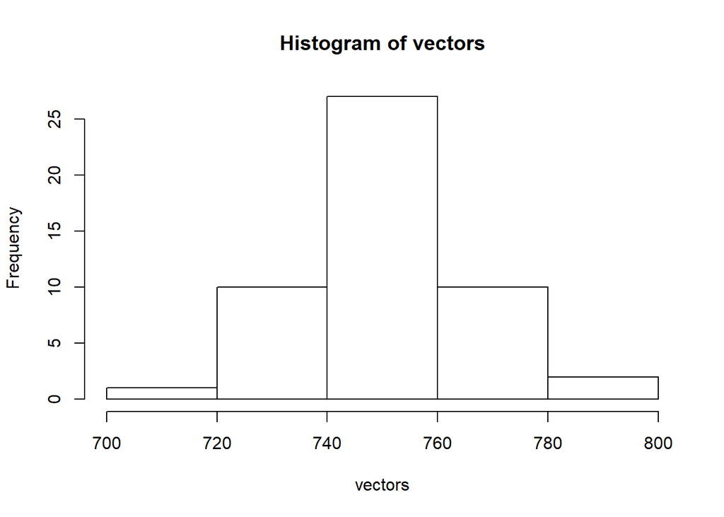

```r
hist(vectors, breaks = 5)
```

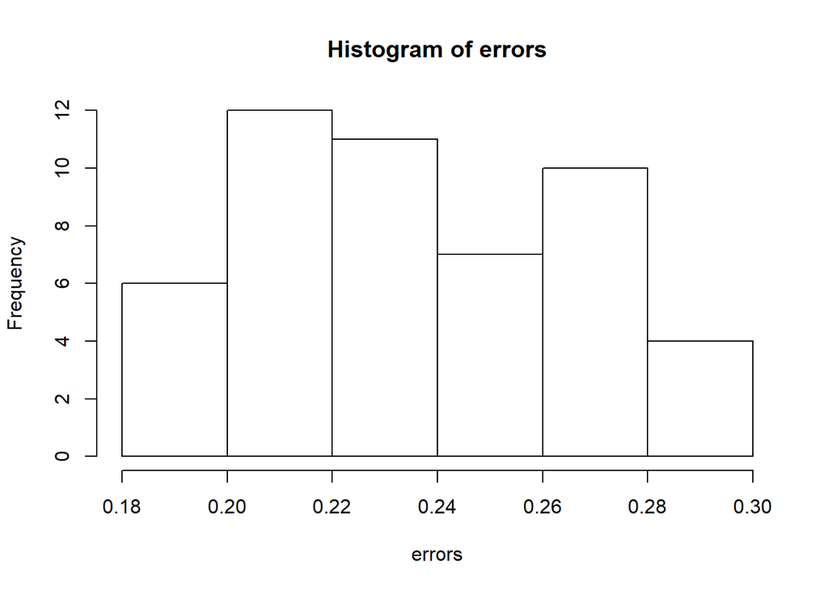

```r
hist(errors, breaks = 5)
```

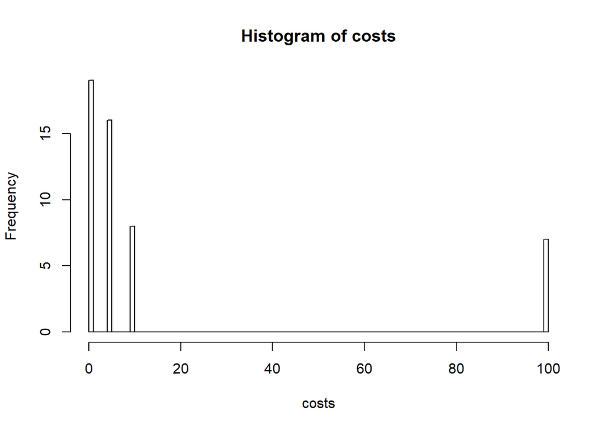

```r
hist(costs, breaks = 100)
```

```r
summary(vectors)
```

```
##    Min. 1st Qu.  Median    Mean 3rd Qu.    Max.
##   714.0   743.0   750.0   751.6   758.8   788.0
```

```r
summary(errors)
```

```
##    Min. 1st Qu.  Median    Mean 3rd Qu.    Max.
##  0.1900  0.2105  0.2320  0.2366  0.2650  0.2860
```

```r
summary(costs)
```

```
##    Min. 1st Qu.  Median    Mean 3rd Qu.    Max.
##   0.001   1.000   5.000  17.400  10.000 100.000
```

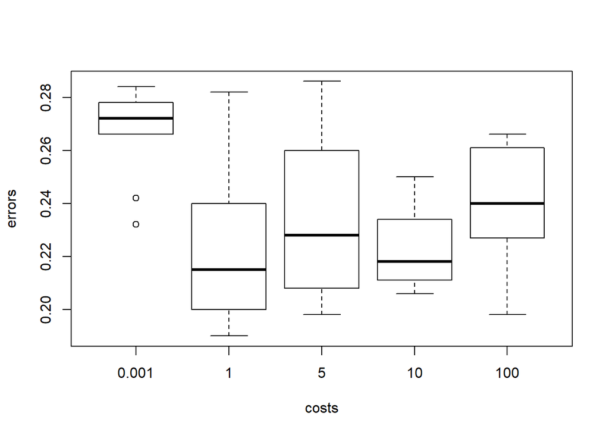

```r
boxplot(errors~costs)
```

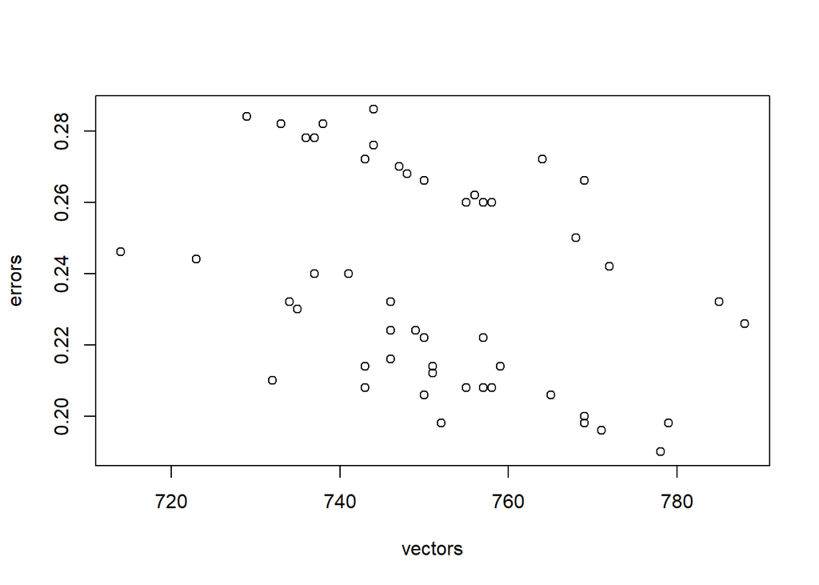

```r
plot(vectors, errors)
```

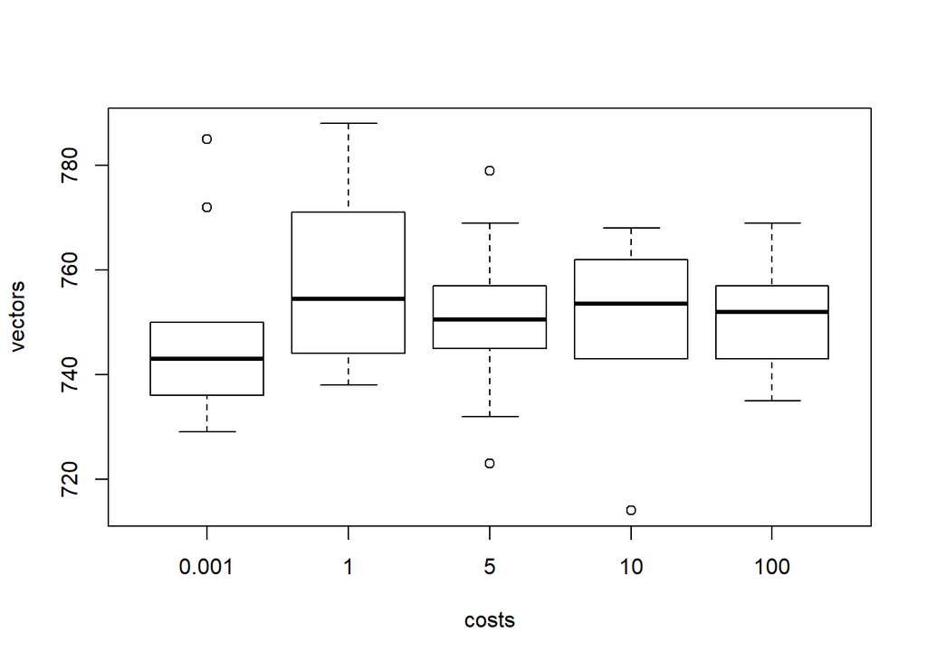

```r
boxplot(vectors~costs)
```

# Problem 2 (10 points): comparison to random forest

Fit random forest classifier on the entire WiFi localization dataset with default parameters. Calculate resulting misclassification error as reported by the confusion matrix in random forest output. Explain why error reported in random forest confusion matrix represents estimated test (as opposed to train) error of the procedure. Compare resulting test error to that for support vector classifier obtained above and discuss results of such comparison.

```r
iterations <- 100
data.point.index <- seq(1,nrow(wifiLocDat))
test.data.size <- 0.25 * nrow(wifiLocDat)
errors <- numeric()

for (i in 1:iterations){
    test.data.index <- sample(data.point.index, size = test.data.size,
                              replace = FALSE)
    test.data <- wifiLocDat[test.data.index,]
    train.data <- wifiLocDat[-test.data.index,]
    rfRes <- randomForest(train.data[,1:7],train.data[,8])
    tt <- table(test.data[,8],predict(rfRes,newdata=test.data[,1:7]))
    errors[i] <- sum(tt[row(tt) != col(tt)]) / sum(tt)
}
```

```r
summary(errors)
```

```
##    Min. 1st Qu.  Median    Mean 3rd Qu.    Max.
##  0.0000  0.0100  0.0140  0.0131  0.0160  0.0280
```

```r
parameter.placeholder <- rep(NA, length(errors))
rf.results <- cbind(errors, parameter.placeholder)
colnames(rf.results) <- c("errors", "parameter")
type.vector <- rep("rf", nrow(rf.results))
rf.results <- cbind(rf.results,type.vector)
rf.results <- as.data.frame(rf.results)
rf.results$errors <- as.numeric(as.character(rf.results$errors))
rf.results$errors <- 100 * rf.results$errors
head(rf.results)
```

```
##   errors parameter type.vector
## 1    0.0      <NA>          rf
## 2    1.2      <NA>          rf
## 3    1.0      <NA>          rf
## 4    2.2      <NA>          rf
## 5    0.8      <NA>          rf
## 6    0.6      <NA>          rf
```

# Problem 3 (10 points): Comparison to cross-validation tuned KNN predictor

Use convenience wrapper `tune.knn` provided by the library `e1071` on the entire dataset to determine optimal value for the number of the nearest neighbors ‘k’ to be used in KNN classifier. Consider our observations from week 9 problem set when choosing range of values of `k` to be evaluated by `tune.knn`. Setup resampling procedure similar to that used above for support vector classifier that will repeatedly: a) split WiFi localization dataset into training and test, b) use `tune.knn` on training data to determine optimal `k`, and c) use `k` estimated by `tune.knn` to make KNN classifications on test data. Report and discuss distributions of test errors from this procedure and selected values of `k`, compare them to those obtained for random forest and support vector classifier above.

```r
tuned.knn <- tune.knn(wifiLocDat[,1:7], wifiLocDat[,8], k=seq(1,10))
tuned.knn
```

```
##
## Parameter tuning of 'knn.wrapper':
##
## - sampling method: 10-fold cross validation
##
## - best parameters:
##  k
##  1
##
## - best performance: 0.0125
```

```r
names(tuned.knn)
```

```
## [1] "best.parameters"  "best.performance" "method"           "nparcomb"
## [5] "train.ind"        "sampling"         "performances"     "best.model"
```

```r
iterations <- 1000
data.point.index <- seq(1,nrow(wifiLocDat))
test.data.size <- 0.25 * nrow(wifiLocDat)
errors <- numeric()
ks <- numeric()

for (i in 1:iterations){
    test.data.index <- sample(data.point.index, size = test.data.size,
                              replace = FALSE)
    test.data <- wifiLocDat[test.data.index,]
    train.data <- wifiLocDat[-test.data.index,]
    tuned.knn <- tune.knn(train.data[,1:7], train.data[,8], k=seq(1,10))
    ks[i] <- tuned.knn$best.parameters[1,1]
    knn.model <- knn(train = train.data[,1:7], test = test.data[,1:7],
                     cl = train.data[,8], k=tuned.knn$best.parameters[1,1])
    predicted <- knn.model
    truth <- test.data[,8]
    errors[i] <- 100-(signif(sum(truth==predicted)*100/length(truth),3))
}
```

```r
summary(errors)
```

```
##    Min. 1st Qu.  Median    Mean 3rd Qu.    Max.
##   0.000   1.200   1.400   1.455   1.800   3.200
```

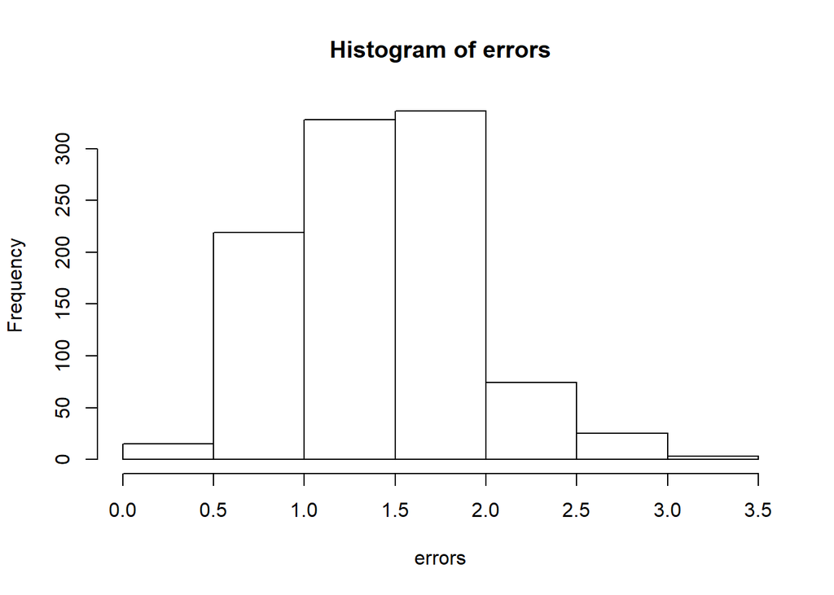

```r
hist(errors)
```

```r
summary(ks)
```

```
##    Min. 1st Qu.  Median    Mean 3rd Qu.    Max.
##   1.000   1.000   3.000   2.519   3.000  10.000
```

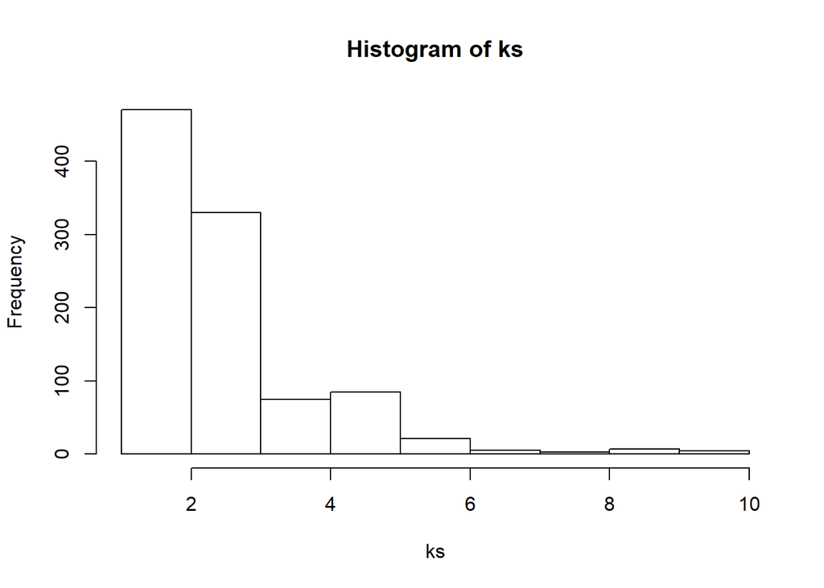

```r
hist(ks)
```

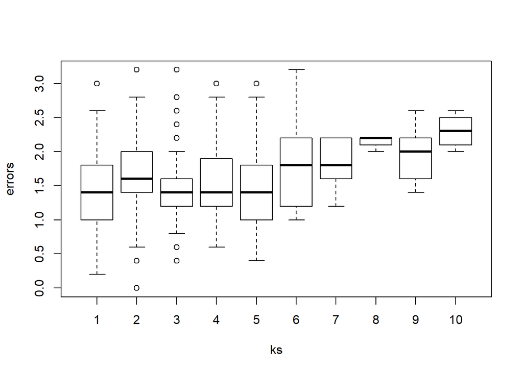

```r
boxplot(errors~ks)
```

Here we see that KNN with k=1 and 3 perform similarly with error rates below 1.5%. These are very similar results to the random forest method in terms of the mean, median, and ranges. Error begins to increase significantly after k=5.

The optimized KNN method performs significantly better than the SVM method.

```r
knn.results <- cbind(errors, ks)
colnames(knn.results) <- c("errors", "parameter")
type.vector <- rep("knn", nrow(knn.results))
knn.results <- cbind(knn.results,type.vector)
knn.results <- as.data.frame(knn.results)
knn.results$errors <- as.numeric(as.character(knn.results$errors))
head(knn.results)
```

```
##   errors parameter type.vector
## 1    1.6         1         knn
## 2    1.6         3         knn
## 3    2.2         7         knn
## 4    2.6         1         knn
## 5    1.6         2         knn
## 6    2.0         5         knn
```

# Problem 4 (20 points): SVM with radial kernel

## Sub-problem 4a (10 points): impact of $gamma$ on classification surface

*Plot* SVM model fit to the WiFi localization dataset using (for the ease of plotting) *only the first and the second attributes* as predictor variables, `kernel="radial"`, `cost=10` and `gamma=5` (see ISLR Ch.9.6.2 for an example of that done with a simulated dataset). You should be able to see in the resulting plot the magenta-cyan (or, in more recent versions of `e1071` – yellow-brown) classification boundary as computed by this model. Produce the same kinds of plots using 0.5 and 50 as values of `gamma` also. Compare classification boundaries between these three plots and describe how they are impacted by the change in the value of `gamma`. Can you trace it back to the role of `gamma` in the equation introducing it with the radial kernel in ISLR?

```r
trimmed.data <- wifiLocDat[,-c(3,4,5,6,7)]
```

```r
# gamma=5:
svmfit <- svm(Loc3~., data=trimmed.data, kernel="radial", cost=10,
              gamma=5, scale=FALSE)
summary(svmfit)
```

```
##
## Call:
## svm(formula = Loc3 ~ ., data = trimmed.data, kernel = "radial", cost = 10,
##     gamma = 5, scale = FALSE)
##
##
## Parameters:
##    SVM-Type:  C-classification
##  SVM-Kernel:  radial
##        cost:  10
##
## Number of Support Vectors:  632
##
##  ( 429 203 )
##
##
## Number of Classes:  2
##
## Levels:
##  FALSE TRUE
```

```r
table(predict(svmfit),trimmed.data$Loc3)
```

```
##
##         FALSE TRUE
##   FALSE  1461   20
##   TRUE     39  480
```

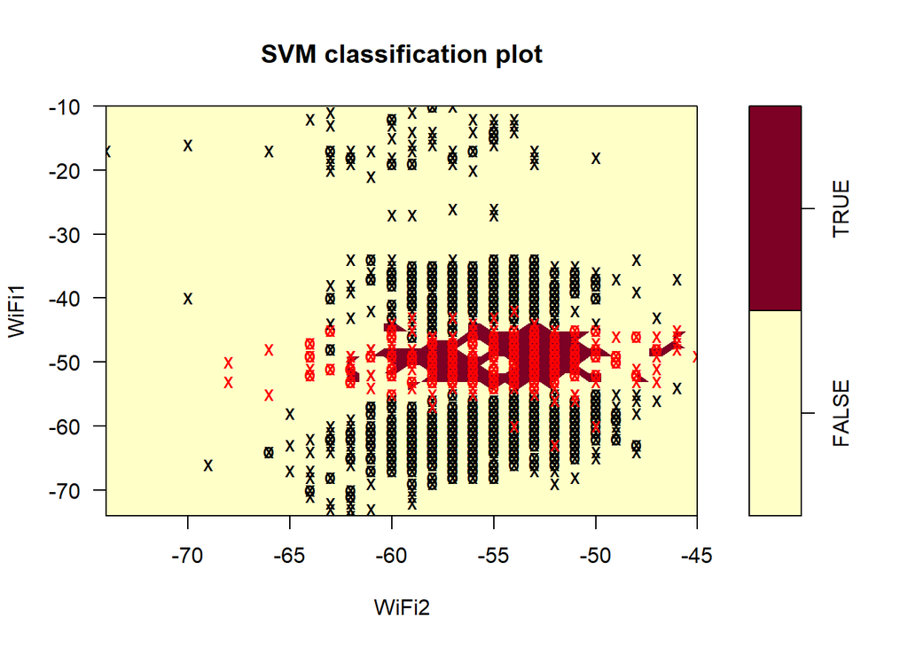

```r
plot(svmfit, trimmed.data)
```

```r
# gamma=0.5:
svmfit <- svm(Loc3~., data=trimmed.data, kernel="radial", cost=10,
              gamma=0.5, scale=FALSE)
summary(svmfit)
```

```
##
## Call:
## svm(formula = Loc3 ~ ., data = trimmed.data, kernel = "radial", cost = 10,
##     gamma = 0.5, scale = FALSE)
##
##
## Parameters:
##    SVM-Type:  C-classification
##  SVM-Kernel:  radial
##        cost:  10
##
## Number of Support Vectors:  538
##
##  ( 340 198 )
##
##
## Number of Classes:  2
##
## Levels:
##  FALSE TRUE
```

```r
table(predict(svmfit),trimmed.data$Loc3)
```

```
##
##         FALSE TRUE
##   FALSE  1453   13
##   TRUE     47  487
```

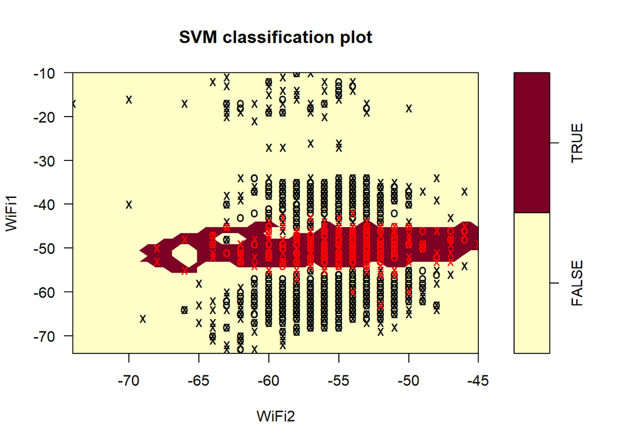

```r
plot(svmfit, trimmed.data)
```

```r
# gamma=50:
svmfit <- svm(Loc3~., data=trimmed.data, kernel="radial", cost=10,
              gamma=50, scale=FALSE)
summary(svmfit)
```

```
##
## Call:
## svm(formula = Loc3 ~ ., data = trimmed.data, kernel = "radial", cost = 10,
##     gamma = 50, scale = FALSE)
##
##
## Parameters:
##    SVM-Type:  C-classification
##  SVM-Kernel:  radial
##        cost:  10
##
## Number of Support Vectors:  629
##
##  ( 429 200 )
##
##
## Number of Classes:  2
##
## Levels:
##  FALSE TRUE
```

```r
table(predict(svmfit),trimmed.data$Loc3)
```

```
##
##         FALSE TRUE
##   FALSE  1461   20
##   TRUE     39  480
```

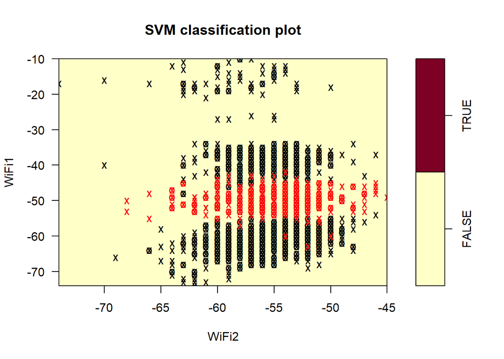

```r
plot(svmfit, trimmed.data)
```

Gamma=5 has distinct decision boundry that appears to perform relatively well in terms of encompassing the correct points.

In the kernel formula gamma is raised to a negative exponential. What this means is that as the value of gamma increases the kernel size for the same summation of x values decreases signficantly. As the kernal approaches very small or very large values it tends to overfit or underfit the data respectively.

## Sub-problem 4b (10 points): test error for SVM with radial kernel

Similar to how it was done above for support vector classifier (and KNN), set up a resampling process that will repeatedly: a) split the entire dataset (using all attributes as predictors) into training and test datasets, b) use `tune` function to determine optimal values of `cost` and `gamma` and c) calculate test error using these values of `cost` and `gamma`. Consider what you have learned above about the effects of the parameters `cost` and `gamma` to decide on the starting ranges of their values to be evaluated by `tune`. Additionally, experiment with different sets of their values and discuss in your solution the results of it and how you would go about selecting those ranges starting from scratch. Present resulting test error graphically, compare it to that of support vector classifier (with linear kernel), random forest and KNN classifiers obtained above and discuss results of these comparisons.

```r
iterations <- 50
data.point.index <- seq(1,nrow(wifiLocDat))
test.data.size <- 0.25 * nrow(wifiLocDat)
errors <- numeric()
vectors <- numeric()
costs <- numeric()
gammas <- numeric()

for (i in 1:iterations){
    test.data.index <- sample(data.point.index, size = test.data.size,
                              replace = FALSE)
    test.data <- wifiLocDat[test.data.index,]
    train.data <- wifiLocDat[-test.data.index,]
    tune.out <- tune(svm, Loc3~., data=train.data, kernel="radial",
                     ranges=list(cost=c(50,70,100), gamma=c(1,5,10)))
    costs[i] <- tune.out$best.parameters[1,1]
    gammas[i] <- tune.out$best.parameters[1,2]
    svmfit <- svm(Loc3~., data=train.data, kernel="radial",
                  cost=tune.out$best.parameters[1,1],
                  gamma=tune.out$best.parameters[1,2])
    ypred <- predict(svmfit, test.data)
    tt <- table(predict=ypred, truth=test.data$Loc3)
    errors[i] <- sum(tt[row(tt) != col(tt)]) / sum(tt)
    vectors[i] <- svmfit$tot.nSV
}
```

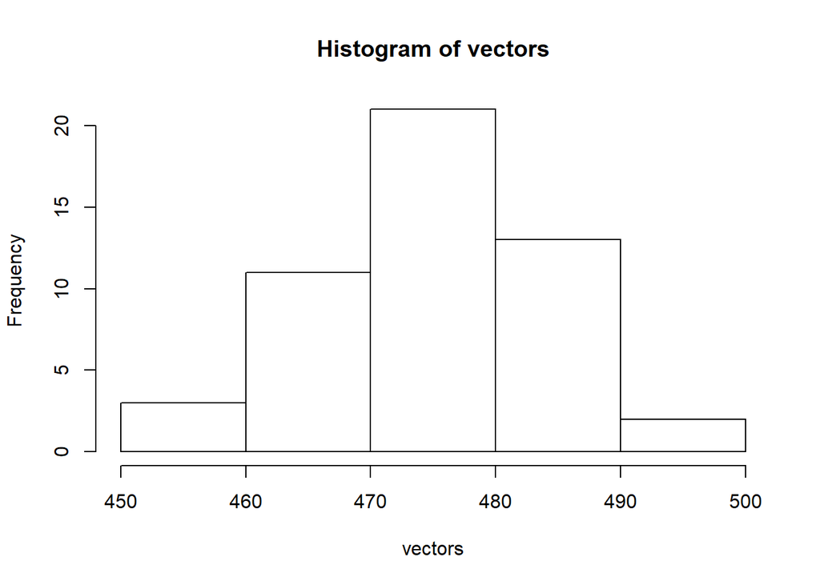

```r
hist(vectors, breaks = 5)
```

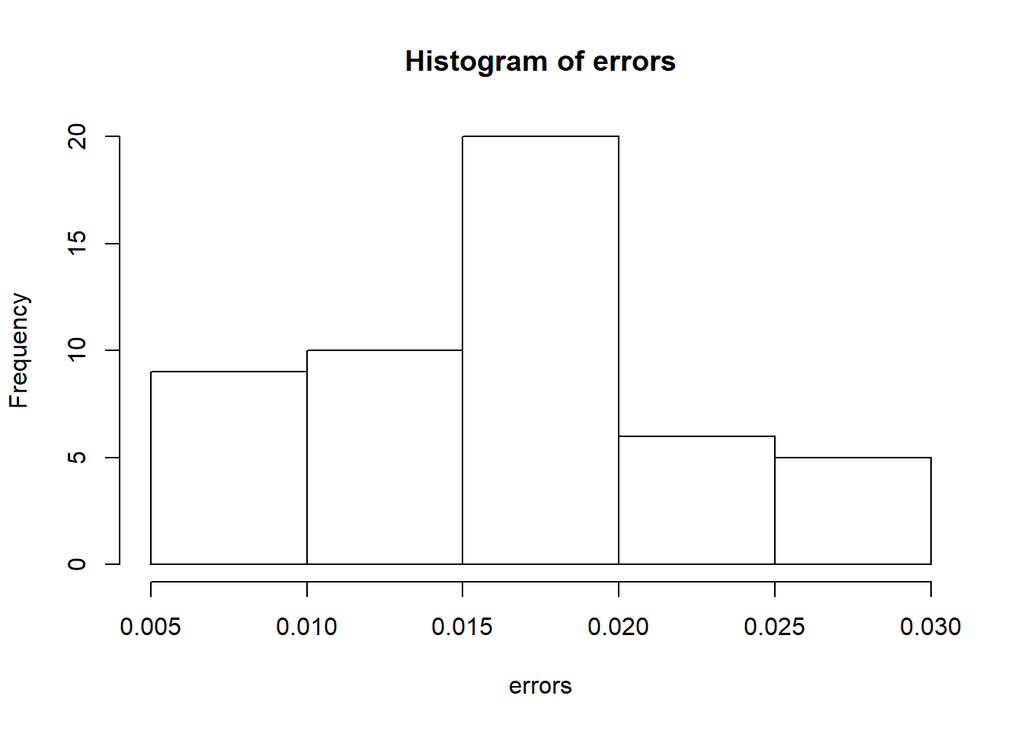

```r
hist(errors, breaks = 5)
```

```r
print("vectors")
```

```
## [1] "vectors"
```

```r
summary(vectors)
```

```
##    Min. 1st Qu.  Median    Mean 3rd Qu.    Max.
##   455.0   470.0   477.5   475.7   482.0   492.0
```

```r
print("errors")
```

```
## [1] "errors"
```

```r
summary(errors)
```

```
##    Min. 1st Qu.  Median    Mean 3rd Qu.    Max.
##  0.0060  0.0120  0.0160  0.0168  0.0200  0.0300
```

```r
print("costs")
```

```
## [1] "costs"
```

```r
summary(costs)
```

```
##    Min. 1st Qu.  Median    Mean 3rd Qu.    Max.
##      50      50      50      50      50      50
```

```r
print("gammas")
```

```
## [1] "gammas"
```

```r
summary(gammas)
```

```
##    Min. 1st Qu.  Median    Mean 3rd Qu.    Max.
##       1       1       1       1       1       1
```

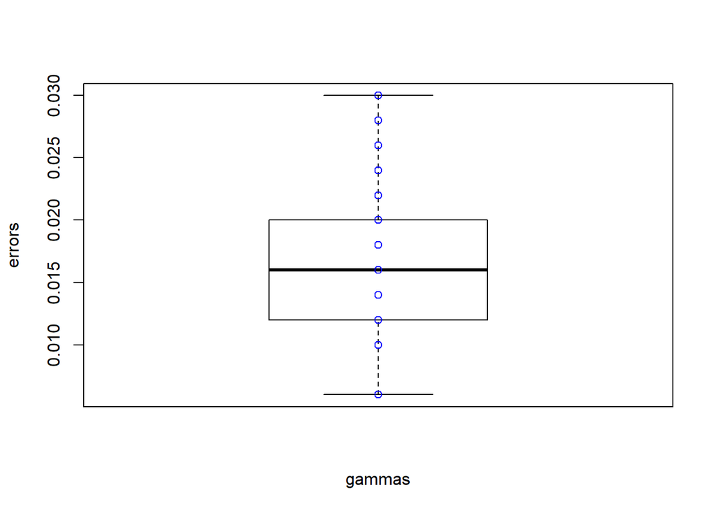

```r
boxplot(errors~gammas)
points(as.factor(gammas), errors,col="blue")
```

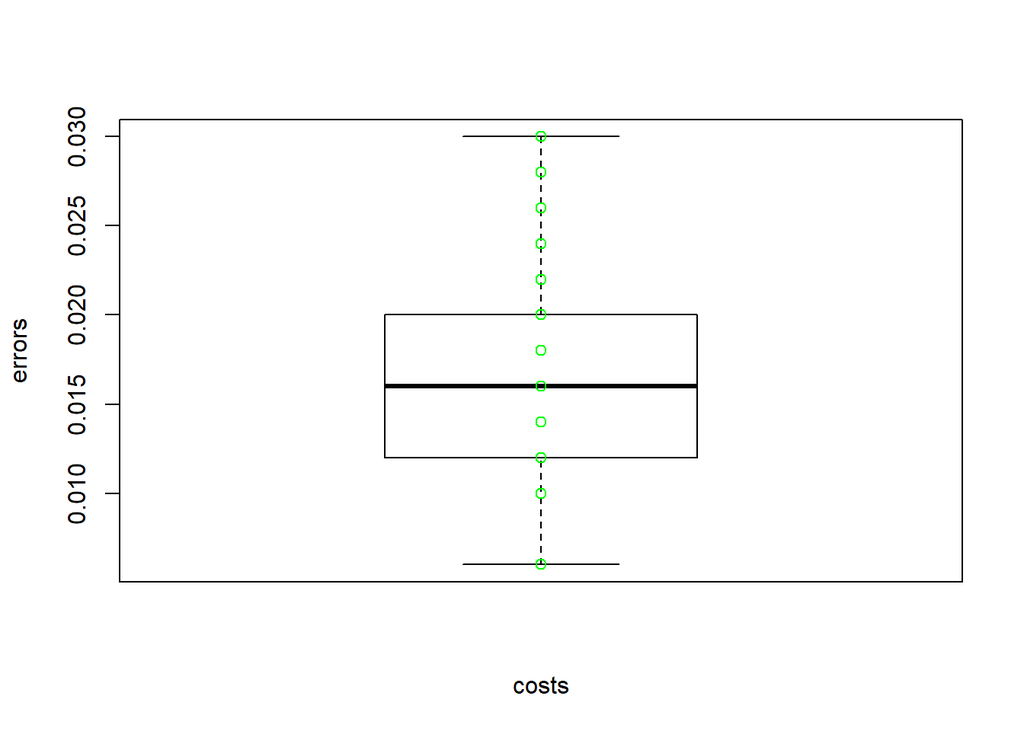

```r
boxplot(errors~costs)
points(as.factor(costs), errors, col="green")
```

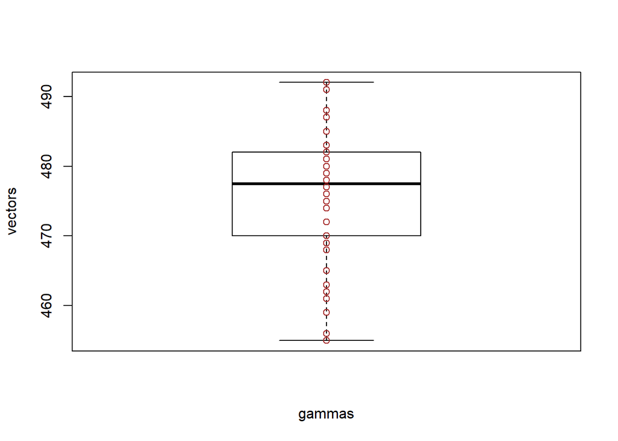

```r
boxplot(vectors~gammas)
points(as.factor(gammas), vectors, col="brown")
```

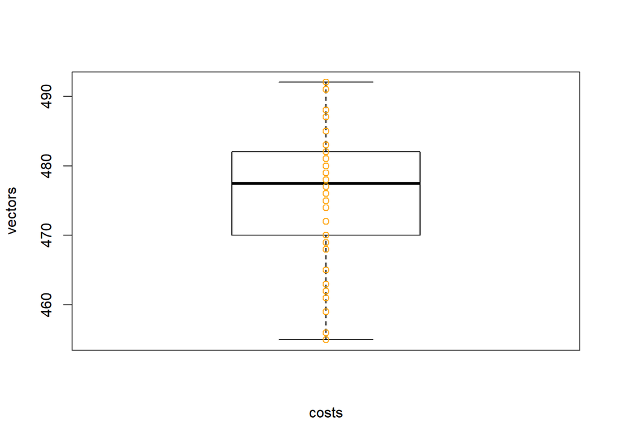

```r
boxplot(vectors~costs)
points(as.factor(costs), vectors, col="orange")
```

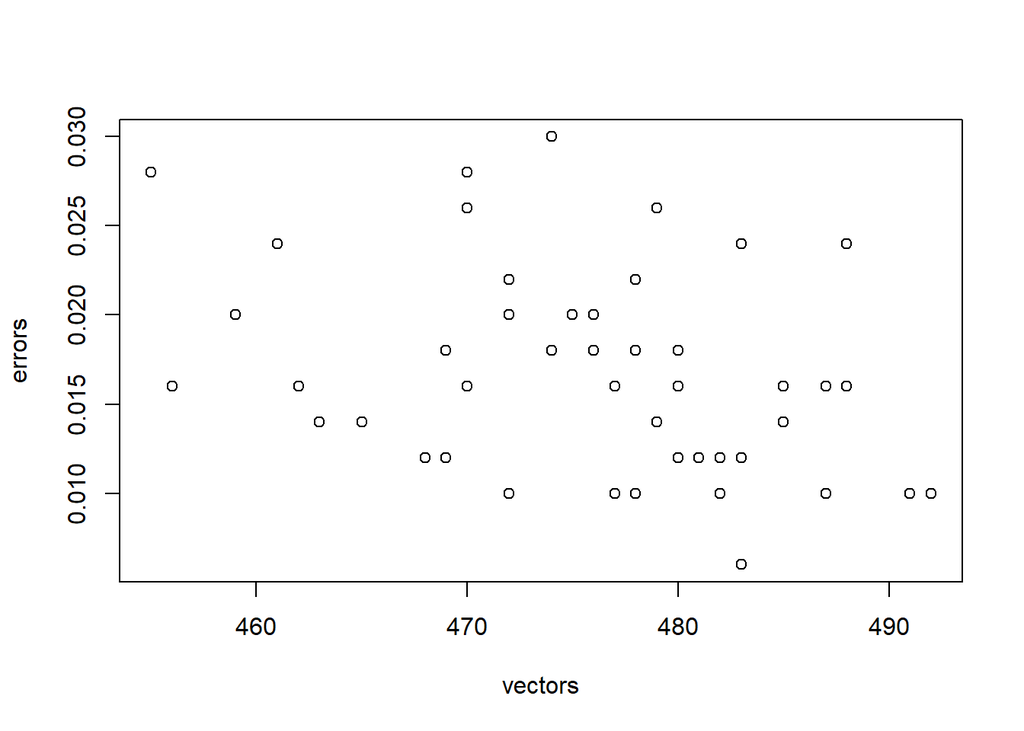

```r
plot(errors~vectors)
```

For every trial, the model picked gamma=1 and cost=50 as the optimal parameter over 50 trials. These parameters are highly stable over 50 trials due to the consistency of the optimal parameter selection.

Over 50 trials, we see normally distributed errors and number of support vectors which also indicates that the number of trials is correct.

Note that the vector distribution has normal-like distributions in relation to the gamma and costs however it the relationship between error and cost and error and gamma is uniform.

```r
svm.results <- cbind(errors, costs)
colnames(svm.results) <- c("errors", "parameter")
type.vector <- rep("svm", nrow(svm.results))
svm.results <- cbind(svm.results,type.vector)
svm.results <- as.data.frame(svm.results)
svm.results$errors <- as.numeric(as.character(svm.results$errors))
svm.results$errors <- 100 * svm.results$errors
head(svm.results)
```

```
##   errors parameter type.vector
## 1    1.2        50         svm
## 2    1.8        50         svm
## 3    2.4        50         svm
## 4    1.0        50         svm
## 5    1.6        50         svm
## 6    1.0        50         svm
```

```r
svm.results$parameter <- NA
results <- rbind(rf.results, knn.results, svm.results)
colnames(results) <- c("error", "k", "model.type")
head(results)
```

```
##   error    k model.type
## 1   0.0 <NA>         rf
## 2   1.2 <NA>         rf
## 3   1.0 <NA>         rf
## 4   2.2 <NA>         rf
## 5   0.8 <NA>         rf
## 6   0.6 <NA>         rf
```

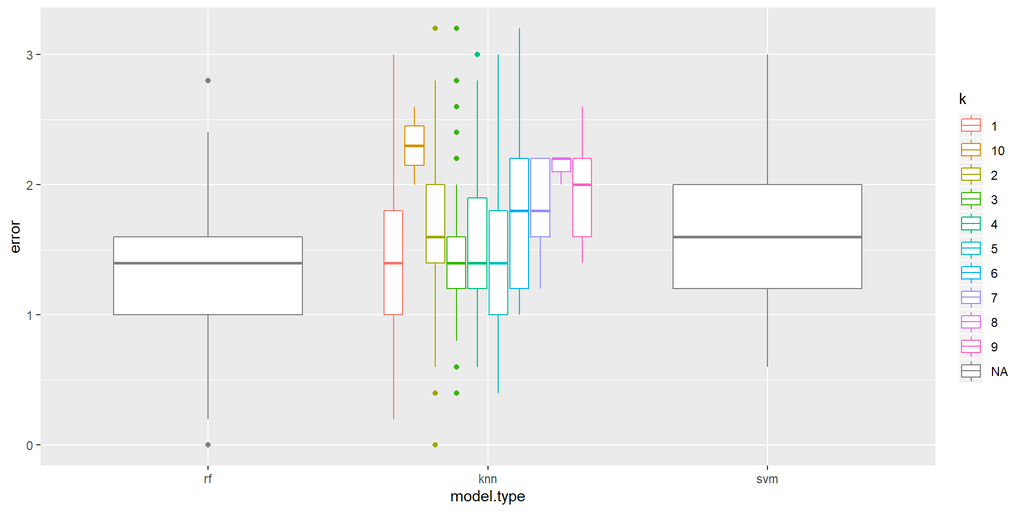

```r
ggplot(results,
       aes(x=model.type, y=error, color=k)) +
    geom_boxplot()
```

The SVM model is competitive however marginally worse than random forest and optimized knn models.

# Extra 5 points problem: SVM with polynomial kernel

Repeat what was done above (plots of decision boundaries for various interesting values of tuning parameters and test error for their best values estimated from training data) using `kernel="polynomial"`. Determine ranges of `coef0`, `degree`, `cost` and `gamma` to be evaluated by `tune`. Present and discuss resulting test error and how it compares to linear and radial kernels and those of random forest and KNN.